# Data Scientist Salaries

## import library

```python
import pandas as pd
import numpy as np
import seaborn as sns
import matplotlib.pyplot as plt
%matplotlib inline
from sklearn import preprocessing
plt.style.use('seaborn')
```

## load the data file

```python
df=pd.read_csv('ds_salaries.csv')
print (df)
```

```
     Unnamed: 0  work_year experience_level employment_type  \
0             0       2020               MI              FT
1             1       2020               SE              FT
2             2       2020               SE              FT
3             3       2020               MI              FT
4             4       2020               SE              FT
..          ...        ...              ...             ...
602         602       2022               SE              FT
603         603       2022               SE              FT
604         604       2022               SE              FT
605         605       2022               SE              FT
606         606       2022               MI              FT

                      job_title  salary salary_currency  salary_in_usd  \
0                Data Scientist   70000             EUR          79833
```

[output cut: 25 more lines]

## Read the first five rows of the data

```python
df.head()
```

|  | Unnamed: 0 | work_year | experience_level | employment_type | job_title | salary | salary_currency | salary_in_usd | employee_residence | remote_ratio | company_location | company_size |
| --- | --- | --- | --- | --- | --- | --- | --- | --- | --- | --- | --- | --- |
| 0 | 0 | 2020 | MI | FT | Data Scientist | 70000 | EUR | 79833 | DE | 0 | DE | L |
| 1 | 1 | 2020 | SE | FT | Machine Learning Scientist | 260000 | USD | 260000 | JP | 0 | JP | S |
| 2 | 2 | 2020 | SE | FT | Big Data Engineer | 85000 | GBP | 109024 | GB | 50 | GB | M |
| 3 | 3 | 2020 | MI | FT | Product Data Analyst | 20000 | USD | 20000 | HN | 0 | HN | S |
| 4 | 4 | 2020 | SE | FT | Machine Learning Engineer | 150000 | USD | 150000 | US | 50 | US | L |

## Knowing the dimensions of the data, the number of rows and columns

```python
df.shape
```

```
(607, 12)
```

## Knowing information about the data and the type of data in the columns

```python
df.info()
```

```
<class 'pandas.core.frame.DataFrame'>
RangeIndex: 607 entries, 0 to 606
Data columns (total 12 columns):
 #   Column              Non-Null Count  Dtype
---  ------              --------------  -----
 0   Unnamed: 0          607 non-null    int64
 1   work_year           607 non-null    int64
 2   experience_level    607 non-null    object
 3   employment_type     607 non-null    object
 4   job_title           607 non-null    object
 5   salary              607 non-null    int64
 6   salary_currency     607 non-null    object
 7   salary_in_usd       607 non-null    int64
 8   employee_residence  607 non-null    object
 9   remote_ratio        607 non-null    int64
 10  company_location    607 non-null    object
 11  company_size        607 non-null    object
dtypes: int64(5), object(7)
memory usage: 57.0+ KB
```

## Make a description of the data and count the mean, median, largest value, std, and smallest value

```python
df.describe()
```

|  | Unnamed: 0 | work_year | salary | salary_in_usd | remote_ratio |
| --- | --- | --- | --- | --- | --- |
| count | 607.000000 | 607.000000 | 6.070000e+02 | 607.000000 | 607.00000 |
| mean | 303.000000 | 2021.405272 | 3.240001e+05 | 112297.869852 | 70.92257 |
| std | 175.370085 | 0.692133 | 1.544357e+06 | 70957.259411 | 40.70913 |
| min | 0.000000 | 2020.000000 | 4.000000e+03 | 2859.000000 | 0.00000 |
| 25% | 151.500000 | 2021.000000 | 7.000000e+04 | 62726.000000 | 50.00000 |
| 50% | 303.000000 | 2022.000000 | 1.150000e+05 | 101570.000000 | 100.00000 |
| 75% | 454.500000 | 2022.000000 | 1.650000e+05 | 150000.000000 | 100.00000 |
| max | 606.000000 | 2022.000000 | 3.040000e+07 | 600000.000000 | 100.00000 |

## Determine the type of data that each column contains

```python
df.dtypes
```

```
Unnamed: 0             int64
work_year              int64
experience_level      object
employment_type       object
job_title             object
salary                 int64
salary_currency       object
salary_in_usd          int64
employee_residence    object
remote_ratio           int64
company_location      object
company_size          object
dtype: object
```

## See if there are any missing values in the data and find the number of missing values in each column

```python
df.isnull().sum()
```

```
Unnamed: 0            0
work_year             0
experience_level      0
employment_type       0
job_title             0
salary                0
salary_currency       0
salary_in_usd         0
employee_residence    0
remote_ratio          0
company_location      0
company_size          0
dtype: int64
```

```python
df.isna().any()
```

```
Unnamed: 0            False
work_year             False
experience_level      False
employment_type       False
job_title             False
salary                False
salary_currency       False
salary_in_usd         False
employee_residence    False
remote_ratio          False
company_location      False
company_size          False
dtype: bool
```

## Items without repeat

Finding the number of items in each column without repetition How many values are in each column without repetition?

```python
df.nunique()
```

```
Unnamed: 0            607
work_year               3
experience_level        4
employment_type         4
job_title              50
salary                272
salary_currency        17
salary_in_usd         369
employee_residence     57
remote_ratio            3
company_location       50
company_size            3
dtype: int64
```

## The value in each column without repetition and the type of those values

Names of the repeated elements that make up a particular column without repetition Find out which items are repeated in each column without repetition

```python
df['experience_level'].unique()
```

```
array(['MI', 'SE', 'EN', 'EX'], dtype=object)
```

```python
df['work_year'].unique()
```

```
array([2020, 2021, 2022], dtype=int64)
```

```python
df['employment_type'].unique()
```

```
array(['FT', 'CT', 'PT', 'FL'], dtype=object)
```

```python
df['job_title'].unique()
```

```
array(['Data Scientist', 'Machine Learning Scientist',
       'Big Data Engineer', 'Product Data Analyst',
       'Machine Learning Engineer', 'Data Analyst', 'Lead Data Scientist',
       'Business Data Analyst', 'Lead Data Engineer', 'Lead Data Analyst',
       'Data Engineer', 'Data Science Consultant', 'BI Data Analyst',
       'Director of Data Science', 'Research Scientist',
       'Machine Learning Manager', 'Data Engineering Manager',
       'Machine Learning Infrastructure Engineer', 'ML Engineer',
       'AI Scientist', 'Computer Vision Engineer',
       'Principal Data Scientist', 'Data Science Manager', 'Head of Data',
       '3D Computer Vision Researcher', 'Data Analytics Engineer',
       'Applied Data Scientist', 'Marketing Data Analyst',
       'Cloud Data Engineer', 'Financial Data Analyst',
       'Computer Vision Software Engineer',
       'Director of Data Engineering', 'Data Science Engineer',
       'Principal Data Engineer', 'Machine Learning Developer',
       'Applied Machine Learning Scientist', 'Data Analytics Manager',
       'Head of Data Science', 'Data Specialist', 'Data Architect',
       'Finance Data Analyst', 'Principal Data Analyst',
       'Big Data Architect', 'Staff Data Scientist', 'Analytics Engineer',
       'ETL Developer', 'Head of Machine Learning', 'NLP Engineer',
       'Lead Machine Learning Engineer', 'Data Analytics Lead'],
      dtype=object)
```

## Finding the highest value in a column

The Larger number in a column

```python
df['salary'].max()
```

```
30400000
```

## Finding the lowest value in a column

The smallest number in a column

```python
df['salary'].min()
```

```
4000
```

## Find the lowest value in a column

and search for the highest value in a column Smallest number in a column and the largest number in the column

```python
df['salary'].agg([min,max])
```

```
min        4000
max    30400000
Name: salary, dtype: int64
```

# Data Visualization

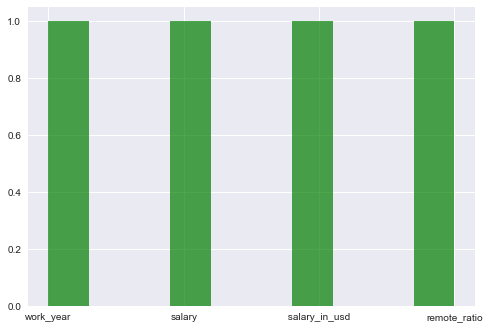

```python
df_b=np.array(['work_year','salary',' salary_in_usd ','remote_ratio'])
plt.hist(df_b,histtype='bar',alpha=.7,color='green',bins=10)
```

## Representation of salary values

```python
sal = df['salary'].value_counts()
sal
```

```
100000     18
80000      18
120000     15
60000      15
150000     14
           ..
256000      1
39600       1
1335000     1
52500       1
129000      1
Name: salary, Length: 272, dtype: int64
```

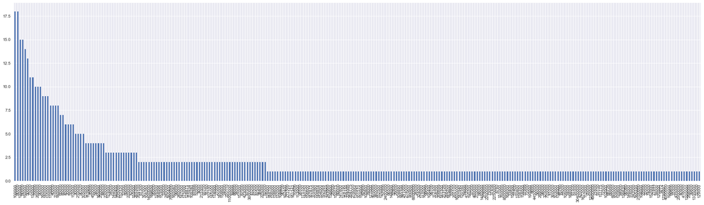

```python
plt.figure(figsize = (30,8))
sal.plot(kind = 'bar')
plt.show()
```

## Create a heat map of the data

Show how each element relates to the other The positive and negative relationships between all the columns

```python
c=df.corr()
print(c)
```

```
               Unnamed: 0  work_year    salary  salary_in_usd  remote_ratio
Unnamed: 0       1.000000   0.886550 -0.096250       0.167025      0.095000
work_year        0.886550   1.000000 -0.087577       0.170493      0.076314
salary          -0.096250  -0.087577  1.000000      -0.083906     -0.014608
salary_in_usd    0.167025   0.170493 -0.083906       1.000000      0.132122
remote_ratio     0.095000   0.076314 -0.014608       0.132122      1.000000
```

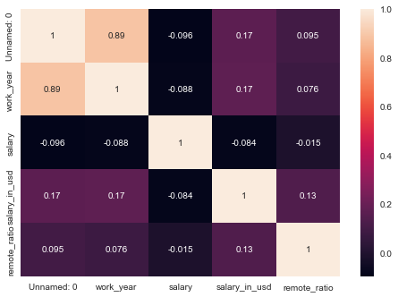

```python
sns.heatmap(c,annot=True)
```

## Relationships between all columns

Each two items separately Double representation of data It shows in different forms the connection of each element to the other

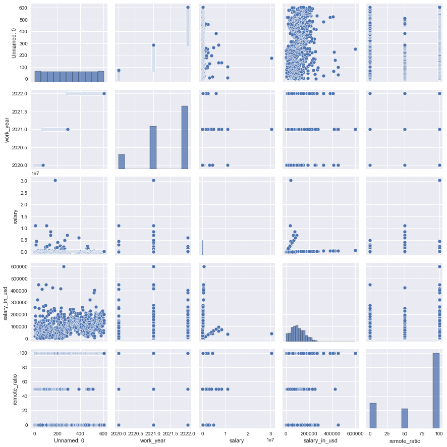

```python
sns.pairplot(df)
```

[figure not shown]